# MyNotes

LongNguyen

1/10/2019

## Load the Gapminder and dplyr packages.

Need to load both gapminder and dplyr for this course. Using filter with pipe %>%. For example, using gapminder %>% filter (year ==2007) will filter dataframe for year =2007

```r
library (gapminder)
library (dplyr)
gapminder %>% filter (country == "United States")
```

```
## # A tibble: 12 x 6
##    country       continent  year lifeExp       pop gdpPercap
##    <fct>         <fct>     <int>   <dbl>     <int>     <dbl>
##  1 United States Americas   1952    68.4 157553000    13990.
##  2 United States Americas   1957    69.5 171984000    14847.
##  3 United States Americas   1962    70.2 186538000    16173.
##  4 United States Americas   1967    70.8 198712000    19530.
##  5 United States Americas   1972    71.3 209896000    21806.
##  6 United States Americas   1977    73.4 220239000    24073.
##  7 United States Americas   1982    74.6 232187835    25010.
##  8 United States Americas   1987    75.0 242803533    29884.
##  9 United States Americas   1992    76.1 256894189    32004.
## 10 United States Americas   1997    76.8 272911760    35767.
## 11 United States Americas   2002    77.3 287675526    39097.
## 12 United States Americas   2007    78.2 301139947    42952.
```

## Arranging observations by life expectancy

```r
gapminder %>% arrange(lifeExp)  #Arrange by life expectancy ascending order
```

```
## # A tibble: 1,704 x 6
##    country      continent  year lifeExp     pop gdpPercap
##    <fct>        <fct>     <int>   <dbl>   <int>     <dbl>
##  1 Rwanda       Africa     1992    23.6 7290203      737.
##  2 Afghanistan  Asia       1952    28.8 8425333      779.
##  3 Gambia       Africa     1952    30    284320      485.
##  4 Angola       Africa     1952    30.0 4232095     3521.
##  5 Sierra Leone Africa     1952    30.3 2143249      880.
##  6 Afghanistan  Asia       1957    30.3 9240934      821.
##  7 Cambodia     Asia       1977    31.2 6978607      525.
##  8 Mozambique   Africa     1952    31.3 6446316      469.
##  9 Sierra Leone Africa     1957    31.6 2295678     1004.
## 10 Burkina Faso Africa     1952    32.0 4469979      543.
## # ... with 1,694 more rows
```

```r
gapminder %>% arrange(desc(lifeExp))
```

```
## # A tibble: 1,704 x 6
##    country          continent  year lifeExp       pop gdpPercap
##    <fct>            <fct>     <int>   <dbl>     <int>     <dbl>
##  1 Japan            Asia       2007    82.6 127467972    31656.
##  2 Hong Kong, China Asia       2007    82.2   6980412    39725.
##  3 Japan            Asia       2002    82   127065841    28605.
##  4 Iceland          Europe     2007    81.8    301931    36181.
##  5 Switzerland      Europe     2007    81.7   7554661    37506.
##  6 Hong Kong, China Asia       2002    81.5   6762476    30209.
##  7 Australia        Oceania    2007    81.2  20434176    34435.
##  8 Spain            Europe     2007    80.9  40448191    28821.
##  9 Sweden           Europe     2007    80.9   9031088    33860.
## 10 Israel           Asia       2007    80.7   6426679    25523.
## # ... with 1,694 more rows
```

## Using a combination of filter and arrange

```r
# Filter for the year 1957, then arrange in descending order of population
gapminder %>% filter(year == 1957) %>% arrange(desc(pop))
```

```
## # A tibble: 142 x 6
##    country        continent  year lifeExp       pop gdpPercap
##    <fct>          <fct>     <int>   <dbl>     <int>     <dbl>
##  1 China          Asia       1957    50.5 637408000      576.
##  2 India          Asia       1957    40.2 409000000      590.
##  3 United States  Americas   1957    69.5 171984000    14847.
##  4 Japan          Asia       1957    65.5  91563009     4318.
##  5 Indonesia      Asia       1957    39.9  90124000      859.
##  6 Germany        Europe     1957    69.1  71019069    10188.
##  7 Brazil         Americas   1957    53.3  65551171     2487.
##  8 United Kingdom Europe     1957    70.4  51430000    11283.
##  9 Bangladesh     Asia       1957    39.3  51365468      662.
## 10 Italy          Europe     1957    67.8  49182000     6249.
## # ... with 132 more rows
```

## Mutate

mutate () function can be used to either change the exisiting column value, or adding new column to the dataframe.PLEASE remember that calling pipe on mutate only affect the return dataframe, not the original gapminder dataframe.

## Data visualization with ggplot2

Example of displaying population and gdpPercap for year 1952

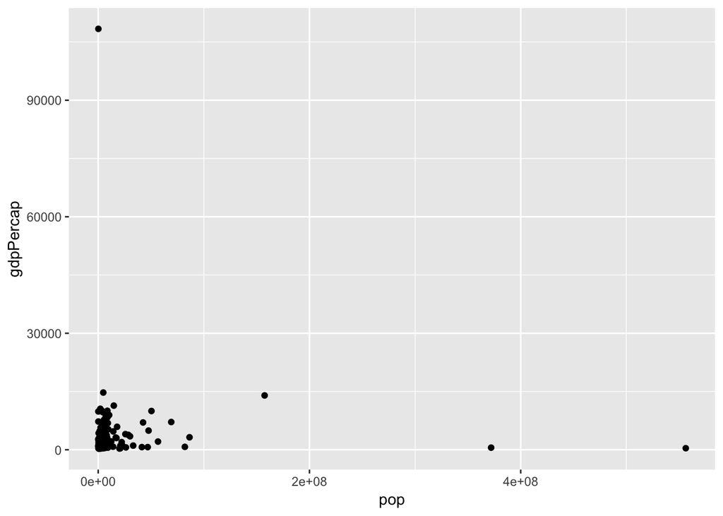

```r
library(ggplot2)  # Need to load the library first.
ggplot(gapminder %>%filter(year==1952), aes(x=pop, y= gdpPercap)) + geom_point()
```

Introducing log_scale by adding: scale_x_log10() or scale_y_log10()

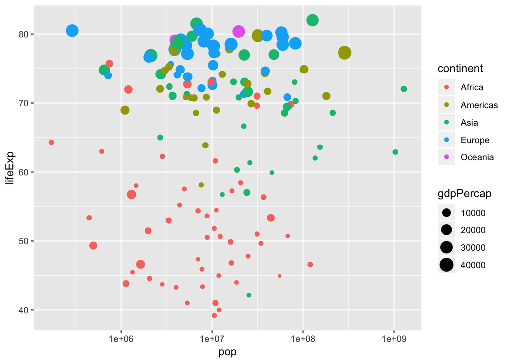

```r
gapminder_2002 <- gapminder %>% filter(year == 2002)
ggplot(gapminder_2002, aes (x= pop, y= lifeExp, color = continent, size = gdpPercap)) + geom_point()+ scale_x_log10()
```

Dividing graph by using faceting

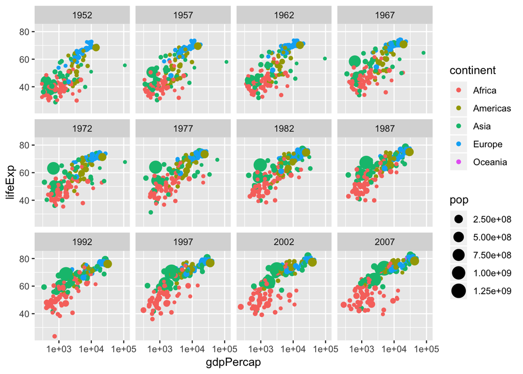

```r
ggplot(gapminder, aes(x= gdpPercap, y= lifeExp, color = continent, size=pop)) + geom_point() + scale_x_log10() + facet_wrap(~year)
```

## Introduction to summarize, group_by,

summarize function summarizes and return one value for the category (year in this course example) group_by() received a column variable that the data will be grouped by.

```r
# Example:
# Code below will display summarize of median life expectancy and max gdpPerCapital for each year.
gapminder %>% group_by(year) %>%summarize(medianLifeExp = median(lifeExp), maxGdpPercap = max(gdpPercap))
```

```
## # A tibble: 12 x 3
##     year medianLifeExp maxGdpPercap
##    <int>         <dbl>        <dbl>
##  1  1952          45.1      108382.
##  2  1957          48.4      113523.
##  3  1962          50.9       95458.
##  4  1967          53.8       80895.
##  5  1972          56.5      109348.
##  6  1977          59.7       59265.
##  7  1982          62.4       33693.
##  8  1987          65.8       31541.
##  9  1992          67.7       34933.
## 10  1997          69.4       41283.
## 11  2002          70.8       44684.
## 12  2007          71.9       49357.
```

Another example, median life expectancy, max GDP Percap groupby continent for year 1957

```r
gapminder %>% filter(year==1957) %>% group_by(continent) %>% summarize(medianLifeExp = median(lifeExp), maxGdpPercap = max(gdpPercap))
```

```
## # A tibble: 5 x 3
##   continent medianLifeExp maxGdpPercap
##   <fct>             <dbl>        <dbl>
## 1 Africa             40.6        5487.
## 2 Americas           56.1       14847.
## 3 Asia               48.3      113523.
## 4 Europe             67.6       17909.
## 5 Oceania            70.3       12247.
```

## Other graphs such as Line graph, Bar graph,

Bar_Graph: geom_col() Line_Graph: geom_line() Histograms: geom_histogram() – Show frequency. Historgram does not require y-axis as in other graph.Using binwidth to adjust the bin size. box_plots: geom_boxplot()

- Adding ggtitle() to add *title* to the graph

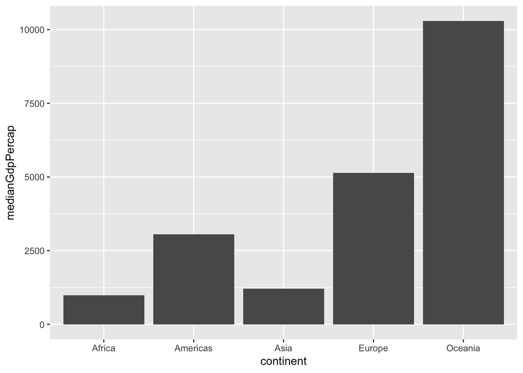

```r
# Display bar graph of median GDP per cap for year 1952 per continent
by_continent <- gapminder%>%filter(year==1952) %>%group_by(continent) %>%summarize(medianGdpPercap = median (gdpPercap))
ggplot(by_continent, aes(x= continent, y= medianGdpPercap)) + geom_col()
```

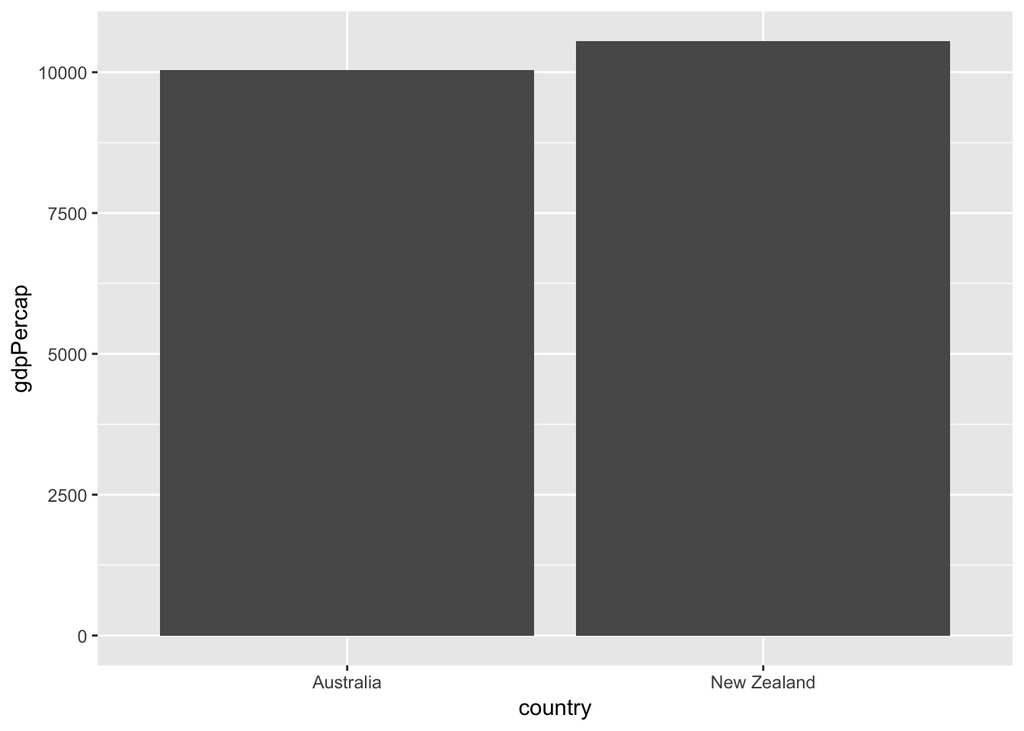

```r
# Another example:
oceania_1952 <- gapminder %>% filter(year == 1952, continent == "Oceania") # filter by year and Oceania
ggplot(oceania_1952, aes(x = country, y= gdpPercap)) + geom_col()
```